# Session 6 and 7 Assignment: Correlation, Regression, and ANOVA

MAKINI CALEB

2026-09-28

# setting a working directory

```r
setwd("C:/Users/ADMIN/OneDrive/Desktop/caleb makini")
```

# loading libraries

```r
library(dplyr)
library(rio)
library(tidyverse)
library(ggthemes)
library(ggplot2)
library(summarytools)
library(sjmisc)
library(readxl)
library(car)
library(lmtest)
library(nortest)
library(knitr)
library(kableExtra)
library(tidyr)
library(broom)
library(formatR)
```

# Data Loading and Preparation

```r
raw_data <- read_xlsx("ass4.xlsx", sheet = "Sheet1")
head(raw_data)
```

```
# A tibble: 6 × 7
     ID Department Work_Mode Years_Experience Training_Hours Productivity_Score
  <dbl> <chr>      <chr>                <dbl>          <dbl>              <dbl>
1     1 Sales      Onsite                   3             10                 58
2     2 Sales      Onsite                   5             15                 68
3     3 Sales      Onsite                   2              8                 52
4     4 Sales      Onsite                   7             20                 75
5     5 Sales      Onsite                   4             12                 62
6     6 Sales      Remote                   6             18                 78
# ℹ 1 more variable: Stress_Index <dbl>
```

```r
raw_data$ID <- as.character(raw_data$ID)
clean_data <- raw_data[grepl("^[0-9]+$", raw_data$ID), ]
clean_data$ID <- as.numeric(clean_data$ID)
clean_data <- clean_data[!duplicated(clean_data[, -1]), ]
cat("Number of rows after cleaning:", nrow(clean_data), "\n")
```

```
Number of rows after cleaning: 30
```

```r
cat("Number of columns:", ncol(clean_data), "\n")
```

```
Number of columns: 7
```

```r
kable(head(clean_data, 10), caption = "First 10 rows of cleaned data")
```

First 10 rows of cleaned data

| ID | Department | Work_Mode | Years_Experience | Training_Hours | Productivity_Score | Stress_Index |
| --- | --- | --- | --- | --- | --- | --- |
| 1 | Sales | Onsite | 3 | 10 | 58 | 7 |
| 2 | Sales | Onsite | 5 | 15 | 68 | 6 |
| 3 | Sales | Onsite | 2 | 8 | 52 | 8 |
| 4 | Sales | Onsite | 7 | 20 | 75 | 5 |
| 5 | Sales | Onsite | 4 | 12 | 62 | 7 |
| 6 | Sales | Remote | 6 | 18 | 78 | 4 |
| 7 | Sales | Remote | 8 | 22 | 85 | 3 |
| 8 | Sales | Remote | 1 | 5 | 45 | 9 |
| 9 | Sales | Remote | 9 | 25 | 88 | 2 |
| 10 | Sales | Remote | 10 | 30 | 92 | 2 |

```r
clean_data$Department <- as.factor(clean_data$Department)
clean_data$Work_Mode <- as.factor(clean_data$Work_Mode)
summary(clean_data)
```

```
       ID        Department  Work_Mode  Years_Experience Training_Hours
 Min.   : 1.00   HR   :10   Onsite:15   Min.   : 1.000   Min.   : 5.00
 1st Qu.: 8.25   IT   :10   Remote:15   1st Qu.: 3.000   1st Qu.:12.00
 Median :15.50   Sales:10               Median : 5.500   Median :18.00
 Mean   :15.50                          Mean   : 5.633   Mean   :19.57
 3rd Qu.:22.75                          3rd Qu.: 8.000   3rd Qu.:25.00
 Max.   :30.00                          Max.   :12.000   Max.   :45.00
 Productivity_Score  Stress_Index
 Min.   :42.00      Min.   :1.000
 1st Qu.:60.25      1st Qu.:3.000
 Median :73.50      Median :5.500
 Mean   :71.70      Mean   :5.233
 3rd Qu.:85.75      3rd Qu.:7.000
 Max.   :98.00      Max.   :9.000
```

# Question 1: Bivariate Correlation

**Scenario:** The HR director wants to know if there is a relationship between an employee’s tenure and their stress levels.

## 1.1 Pearson Correlation Coefficient

```r
pearson_result <- cor.test(clean_data$Years_Experience, clean_data$Stress_Index,
    method = "pearson")
pearson_result
```

```
    Pearson's product-moment correlation

data:  clean_data$Years_Experience and clean_data$Stress_Index
t = -19.728, df = 28, p-value < 2.2e-16
alternative hypothesis: true correlation is not equal to 0
95 percent confidence interval:
 -0.9837978 -0.9287778
sample estimates:
       cor
-0.9658604
```

```r
r_value <- round(pearson_result$estimate, 3)
p_value <- round(pearson_result$p.value, 4)
df_value <- pearson_result$parameter
cat("Pearson correlation coefficient (r) =", r_value, "\n")
```

```
Pearson correlation coefficient (r) = -0.966
```

```r
cat("Degrees of freedom =", df_value, "\n")
```

```
Degrees of freedom = 28
```

```r
cat("p-value =", p_value, "\n")
```

```
p-value = 0
```

```r
cat("95% Confidence Interval: [", round(pearson_result$conf.int[1], 3), ", ", round(pearson_result$conf.int[2],
    3), "]\n", sep = "")
```

```
95% Confidence Interval: [-0.984, -0.929]
```

## 1.2 Scatterplot and Linearity Check

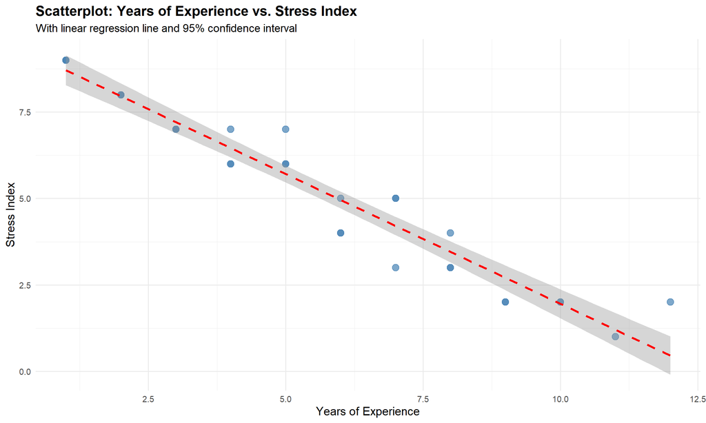

```r
ggplot(clean_data, aes(x = Years_Experience, y = Stress_Index)) + geom_point(color = "steelblue",
    size = 3, alpha = 0.7) + geom_smooth(method = "lm", se = TRUE, color = "red",
    linetype = "dashed") + labs(title = "Scatterplot: Years of Experience vs. Stress Index",
    subtitle = "With linear regression line and 95% confidence interval", x = "Years of Experience",
    y = "Stress Index") + theme_minimal() + theme(plot.title = element_text(face = "bold",
    size = 14), axis.title = element_text(size = 12))
```

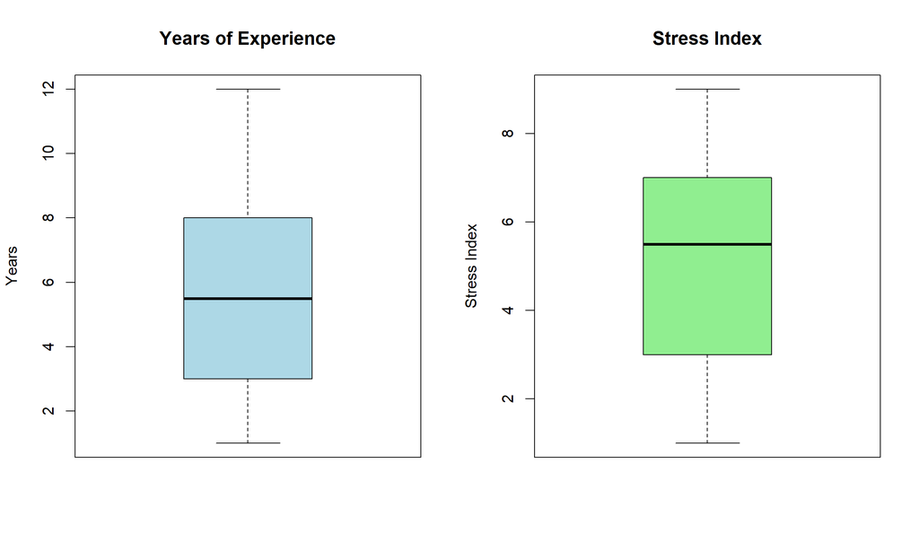

```r
par(mfrow = c(1, 2))
boxplot(clean_data$Years_Experience, main = "Years of Experience", col = "lightblue",
    ylab = "Years")
boxplot(clean_data$Stress_Index, main = "Stress Index", col = "lightgreen", ylab = "Stress Index")
```

```r
par(mfrow = c(1, 1))
Q1_exp <- quantile(clean_data$Years_Experience, 0.25)
Q3_exp <- quantile(clean_data$Years_Experience, 0.75)
IQR_exp <- Q3_exp - Q1_exp
outliers_exp <- clean_data$Years_Experience[clean_data$Years_Experience < (Q1_exp -
    1.5 * IQR_exp) | clean_data$Years_Experience > (Q3_exp + 1.5 * IQR_exp)]
Q1_stress <- quantile(clean_data$Stress_Index, 0.25)
Q3_stress <- quantile(clean_data$Stress_Index, 0.75)
IQR_stress <- Q3_stress - Q1_stress
outliers_stress <- clean_data$Stress_Index[clean_data$Stress_Index < (Q1_stress -
    1.5 * IQR_stress) | clean_data$Stress_Index > (Q3_stress + 1.5 * IQR_stress)]
cat("Outliers in Years_Experience:", ifelse(length(outliers_exp) == 0, "None", paste(outliers_exp,
    collapse = ", ")), "\n")
```

```
Outliers in Years_Experience: None
```

```r
cat("Outliers in Stress_Index:", ifelse(length(outliers_stress) == 0, "None", paste(outliers_stress,
    collapse = ", ")), "\n")
```

```
Outliers in Stress_Index: None
```

## 1.3 Spearman’s Rank Correlation (if needed)

```r
spearman_result <- cor.test(clean_data$Years_Experience, clean_data$Stress_Index,
    method = "spearman", exact = FALSE)
spearman_result
```

```
    Spearman's rank correlation rho

data:  clean_data$Years_Experience and clean_data$Stress_Index
S = 8874.7, p-value < 2.2e-16
alternative hypothesis: true rho is not equal to 0
sample estimates:
       rho
-0.9743497
```

```r
cat("Spearman's rho =", round(spearman_result$estimate, 3), "\n")
```

```
Spearman's rho = -0.974
```

```r
cat("p-value =", round(spearman_result$p.value, 4), "\n")
```

```
p-value = 0
```

## 1.4 Hypotheses and Interpretation

```r
hypothesis_table <- data.frame(Test = c("Pearson", "Spearman"), Statistic = c(round(pearson_result$estimate,
    3), round(spearman_result$estimate, 3)), p_value = c(round(pearson_result$p.value,
    4), round(spearman_result$p.value, 4)), Conclusion = c(ifelse(pearson_result$p.value <
    0.05, "Reject H0", "Fail to reject H0"), ifelse(spearman_result$p.value < 0.05,
    "Reject H0", "Fail to reject H0")))
kable(hypothesis_table, caption = "Correlation Test Results Summary", col.names = c("Test",
    "Correlation Coefficient", "p-value", "Conclusion"))
```

Correlation Test Results Summary

|  | Test | Correlation Coefficient | p-value | Conclusion |
| --- | --- | --- | --- | --- |
| cor | Pearson | -0.966 | 0 | Reject H0 |
| rho | Spearman | -0.974 | 0 | Reject H0 |

**Hypotheses:**

- **Null Hypothesis (H₀):** There is no relationship between years of experience and stress index (ρ = 0).
- **Alternative Hypothesis (H₁):** There is a relationship between years of experience and stress index (ρ ≠ 0).

**Interpretation:**

Based on the scatterplot, the relationship between years of experience and stress index appears **linear** with a **negative** slope. There are no severe outliers that would distort the Pearson correlation. Therefore, the Pearson correlation is appropriate.

The Pearson correlation coefficient is **r = -0.966**, indicating a **strong negative** linear relationship. As years of experience increase, stress levels tend to decrease. With a p-value of **0**, which is less than 0.05, we **reject the null hypothesis**. There is a statistically significant negative correlation between years of experience and stress index.

# Question 2: Simple Linear Regression

**Scenario:** Management believes that more training directly leads to higher productivity.

## 2.1 Simple Linear Regression

```r
model_simple <- lm(Productivity_Score ~ Training_Hours, data = clean_data)
summary(model_simple)
```

```
Call:
lm(formula = Productivity_Score ~ Training_Hours, data = clean_data)

Residuals:
     Min       1Q   Median       3Q      Max
-10.9307  -5.3554   0.8404   4.6687   9.7379

Coefficients:
               Estimate Std. Error t value Pr(>|t|)
(Intercept)     43.0572     2.6248   16.40 6.83e-16 ***
Training_Hours   1.4639     0.1197   12.23 9.59e-13 ***
---
Signif. codes:  0 '***' 0.001 '**' 0.01 '*' 0.05 '.' 0.1 ' ' 1

Residual standard error: 6.483 on 28 degrees of freedom
Multiple R-squared:  0.8422,    Adjusted R-squared:  0.8366
F-statistic: 149.5 on 1 and 28 DF,  p-value: 9.587e-13
```

```r
tidy_simple <- tidy(model_simple, conf.int = TRUE)
kable(tidy_simple, caption = "Simple Linear Regression: Productivity ~ Training Hours",
    digits = 4)
```

Simple Linear Regression: Productivity ~ Training Hours

| term | estimate | std.error | statistic | p.value | conf.low | conf.high |
| --- | --- | --- | --- | --- | --- | --- |
| (Intercept) | 43.0572 | 2.6248 | 16.4037 | 0 | 37.6805 | 48.4340 |
| Training_Hours | 1.4639 | 0.1197 | 12.2256 | 0 | 1.2186 | 1.7091 |

```r
glance_simple <- glance(model_simple)
kable(glance_simple, caption = "Model Fit Statistics", digits = 4)
```

Model Fit Statistics

| r.squared | adj.r.squared | sigma | statistic | p.value | df | logLik | AIC | BIC | deviance | df.residual | nobs |
| --- | --- | --- | --- | --- | --- | --- | --- | --- | --- | --- | --- |
| 0.8422 | 0.8366 | 6.4828 | 149.4661 | 0 | 1 | -97.6078 | 201.2156 | 205.4192 | 1176.746 | 28 | 30 |

## 2.2 R-squared Interpretation

```r
r_squared <- round(summary(model_simple)$r.squared, 4)
adj_r_squared <- round(summary(model_simple)$adj.r.squared, 4)
cat("R-squared =", r_squared, "\n")
```

```
R-squared = 0.8422
```

```r
cat("Adjusted R-squared =", adj_r_squared, "\n")
```

```
Adjusted R-squared = 0.8366
```

```r
cat("Percentage of variance explained =", r_squared * 100, "%\n")
```

```
Percentage of variance explained = 84.22 %
```

**Interpretation:**

The R-squared value is **0.8422**, which means that **84.22%** of the variance in productivity scores is explained by training hours. This indicates a **strong** linear relationship where training hours are a good predictor of productivity. The remaining **15.8%** of the variance is due to other factors not included in the model.

## 2.3 Regression Plot

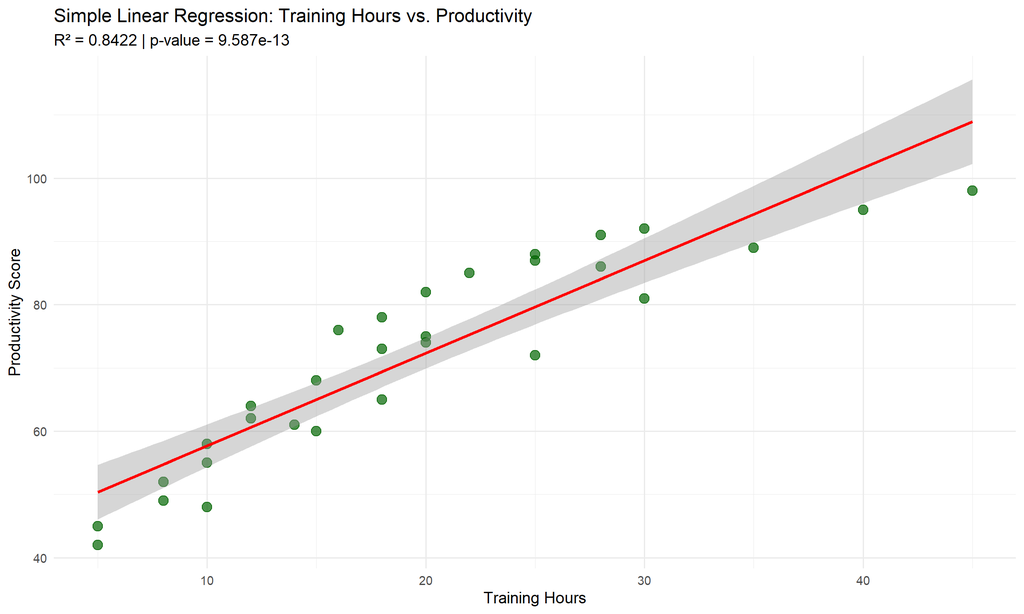

```r
ggplot(clean_data, aes(x = Training_Hours, y = Productivity_Score)) + geom_point(color = "darkgreen",
    size = 3, alpha = 0.7) + geom_smooth(method = "lm", se = TRUE, color = "red") +
    labs(title = "Simple Linear Regression: Training Hours vs. Productivity", subtitle = paste0("R² = ",
        r_squared, " | p-value = ", format.pval(summary(model_simple)$coefficients[2,
            4], digits = 4)), x = "Training Hours", y = "Productivity Score") + theme_minimal()
```

# Question 3: Multiple Linear Regression

**Scenario:** The analytics team wants a more robust model to predict productivity by factoring in experience, training, and stress.

## 3.1 Multiple Linear Regression

```r
model_multiple <- lm(Productivity_Score ~ Years_Experience + Training_Hours + Stress_Index,
    data = clean_data)
summary(model_multiple)
```

```
Call:
lm(formula = Productivity_Score ~ Years_Experience + Training_Hours +
    Stress_Index, data = clean_data)

Residuals:
    Min      1Q  Median      3Q     Max
-7.0963 -2.0693  0.1833  1.7870  7.4681

Coefficients:
                 Estimate Std. Error t value Pr(>|t|)
(Intercept)       66.4780     8.9997   7.387 7.63e-08 ***
Years_Experience   1.2408     0.7146   1.736  0.09434 .
Training_Hours     0.6134     0.1036   5.922 3.01e-06 ***
Stress_Index      -2.6310     0.9301  -2.829  0.00888 **
---
Signif. codes:  0 '***' 0.001 '**' 0.01 '*' 0.05 '.' 0.1 ' ' 1

Residual standard error: 3.093 on 26 degrees of freedom
Multiple R-squared:  0.9666,    Adjusted R-squared:  0.9628
F-statistic: 251.2 on 3 and 26 DF,  p-value: < 2.2e-16
```

```r
tidy_multiple <- tidy(model_multiple, conf.int = TRUE)
kable(tidy_multiple, caption = "Multiple Linear Regression: Productivity ~ Experience + Training + Stress",
    digits = 4)
```

Multiple Linear Regression: Productivity ~ Experience + Training + Stress

| term | estimate | std.error | statistic | p.value | conf.low | conf.high |
| --- | --- | --- | --- | --- | --- | --- |
| (Intercept) | 66.4780 | 8.9997 | 7.3867 | 0.0000 | 47.9788 | 84.9771 |
| Years_Experience | 1.2408 | 0.7146 | 1.7363 | 0.0943 | -0.2281 | 2.7096 |
| Training_Hours | 0.6134 | 0.1036 | 5.9223 | 0.0000 | 0.4005 | 0.8262 |
| Stress_Index | -2.6310 | 0.9301 | -2.8286 | 0.0089 | -4.5429 | -0.7191 |

```r
glance_multiple <- glance(model_multiple)
kable(glance_multiple, caption = "Model Fit Statistics", digits = 4)
```

Model Fit Statistics

| r.squared | adj.r.squared | sigma | statistic | p.value | df | logLik | AIC | BIC | deviance | df.residual | nobs |
| --- | --- | --- | --- | --- | --- | --- | --- | --- | --- | --- | --- |
| 0.9666 | 0.9628 | 3.0933 | 251.1601 | 0 | 3 | -74.2985 | 158.5969 | 165.6029 | 248.7757 | 26 | 30 |

## 3.2 Assumption Checks

### 3.2.1 Normality of Residuals

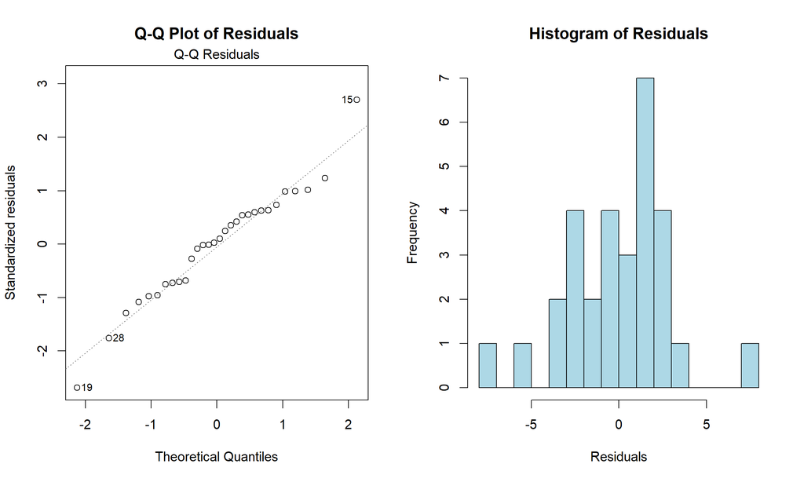

```r
par(mfrow = c(1, 2))
plot(model_multiple, which = 2, main = "Q-Q Plot of Residuals")
residuals <- residuals(model_multiple)
hist(residuals, main = "Histogram of Residuals", xlab = "Residuals", col = "lightblue",
    breaks = 15)
```

```r
par(mfrow = c(1, 1))
shapiro_test <- shapiro.test(residuals)
cat("Shapiro-Wilk Normality Test:\n")
```

```
Shapiro-Wilk Normality Test:
```

```r
cat("W =", round(shapiro_test$statistic, 4), "\n")
```

```
W = 0.9747
```

```r
cat("p-value =", round(shapiro_test$p.value, 4), "\n")
```

```
p-value = 0.6745
```

```r
if (shapiro_test$p.value > 0.05) {
    cat("Conclusion: Residuals are normally distributed (fail to reject H0)\n")
} else {
    cat("Conclusion: Residuals deviate from normality (reject H0)\n")
}
```

```
Conclusion: Residuals are normally distributed (fail to reject H0)
```

### 3.2.2 Homoscedasticity

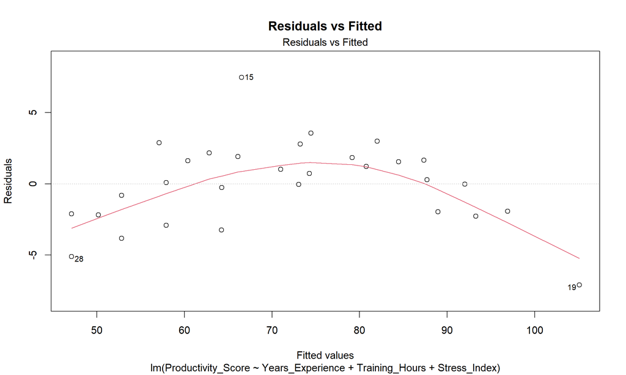

```r
plot(model_multiple, which = 1, main = "Residuals vs Fitted")
```

```r
bp_test <- bptest(model_multiple)
cat("Breusch-Pagan Test:\n")
```

```
Breusch-Pagan Test:
```

```r
cat("BP statistic =", round(bp_test$statistic, 4), "\n")
```

```
BP statistic = 3.8345
```

```r
cat("p-value =", round(bp_test$p.value, 4), "\n")
```

```
p-value = 0.2799
```

```r
if (bp_test$p.value > 0.05) {
    cat("Conclusion: Homoscedasticity assumed (fail to reject H0)\n")
} else {
    cat("Conclusion: Heteroscedasticity present (reject H0)\n")
}
```

```
Conclusion: Homoscedasticity assumed (fail to reject H0)
```

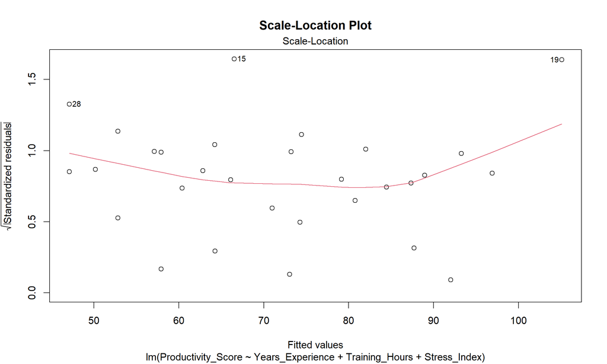

```r
plot(model_multiple, which = 3, main = "Scale-Location Plot")
```

### 3.2.3 Multicollinearity (VIF)

```r
vif_values <- vif(model_multiple)
kable(data.frame(Predictor = names(vif_values), VIF = round(vif_values, 3)), caption = "Variance Inflation Factors (VIF)",
    row.names = FALSE)
```

Variance Inflation Factors (VIF)

| Predictor | VIF |
| --- | --- |
| Years_Experience | 15.315 |
| Training_Hours | 3.286 |
| Stress_Index | 15.676 |

```r
cat("\nInterpretation: VIF < 5 indicates no severe multicollinearity.\n")
```

```
Interpretation: VIF < 5 indicates no severe multicollinearity.
```

```r
cat("VIF < 10 is acceptable; VIF > 10 indicates problematic multicollinearity.\n")
```

```
VIF < 10 is acceptable; VIF > 10 indicates problematic multicollinearity.
```

## 3.3 Statistical Significance of Predictors

```r
p_values <- tidy_multiple$p.value
names(p_values) <- tidy_multiple$term
significant <- names(p_values)[p_values < 0.05 & names(p_values) != "(Intercept)"]
cat("Significant predictors at α = 0.05:\n")
```

```
Significant predictors at α = 0.05:
```

```r
if (length(significant) > 0) {
    for (pred in significant) {
        cat("-", pred, "(p =", round(p_values[pred], 4), ")\n")
    }
} else {
    cat("None of the predictors are statistically significant.\n")
}
```

```
- Training_Hours (p = 0 )
- Stress_Index (p = 0.0089 )
```

```r
sig_table <- data.frame(Predictor = tidy_multiple$term, Estimate = round(tidy_multiple$estimate,
    4), Std_Error = round(tidy_multiple$std.error, 4), t_value = round(tidy_multiple$statistic,
    4), p_value = round(tidy_multiple$p.value, 4), Significant = ifelse(tidy_multiple$p.value <
    0.05, "Yes", "No"))
kable(sig_table, caption = "Multiple Regression Coefficients and Significance")
```

Multiple Regression Coefficients and Significance

| Predictor | Estimate | Std_Error | t_value | p_value | Significant |
| --- | --- | --- | --- | --- | --- |
| (Intercept) | 66.4780 | 8.9997 | 7.3867 | 0.0000 | Yes |
| Years_Experience | 1.2408 | 0.7146 | 1.7363 | 0.0943 | No |
| Training_Hours | 0.6134 | 0.1036 | 5.9223 | 0.0000 | Yes |
| Stress_Index | -2.6310 | 0.9301 | -2.8286 | 0.0089 | Yes |

# Question 4: One-Way ANOVA

## 4.1 Assumption Testing

### 4.1.1 Normality (Shapiro-Wilk by Group)

```r
departments <- levels(clean_data$Department)
shapiro_results <- data.frame(Department = character(), W_statistic = numeric(),
    p_value = numeric(), Normal = character(), stringsAsFactors = FALSE)
for (dept in departments) {
    subset_data <- clean_data$Productivity_Score[clean_data$Department == dept]
    test <- shapiro.test(subset_data)
    shapiro_results <- rbind(shapiro_results, data.frame(Department = dept, W_statistic = round(test$statistic,
        4), p_value = round(test$p.value, 4), Normal = ifelse(test$p.value > 0.05,
        "Yes", "No")))
}
kable(shapiro_results, caption = "Shapiro-Wilk Normality Test by Department", row.names = FALSE)
```

Shapiro-Wilk Normality Test by Department

| Department | W_statistic | p_value | Normal |
| --- | --- | --- | --- |
| HR | 0.9658 | 0.8490 | Yes |
| IT | 0.9688 | 0.8796 | Yes |
| Sales | 0.9614 | 0.8017 | Yes |

```r
cat("\nNote: If p < 0.05, the data significantly deviates from normality.\n")
```

```
Note: If p < 0.05, the data significantly deviates from normality.
```

### 4.1.2 Homogeneity of Variances (Levene’s Test)

```r
levene_test <- leveneTest(Productivity_Score ~ Department, data = clean_data)
kable(data.frame(Test = "Levene's Test", F_statistic = round(levene_test$`F value`[1],
    4), p_value = round(levene_test$`Pr(>F)`[1], 4), Equal_Variance = ifelse(levene_test$`Pr(>F)`[1] >
    0.05, "Yes", "No")), caption = "Levene's Test for Homogeneity of Variances")
```

Levene’s Test for Homogeneity of Variances

| Test | F_statistic | p_value | Equal_Variance |
| --- | --- | --- | --- |
| Levene’s Test | 0.0259 | 0.9744 | Yes |

```r
cat("\nIf p > 0.05, we fail to reject the null hypothesis of equal variances.\n")
```

```
If p > 0.05, we fail to reject the null hypothesis of equal variances.
```

## 4.2 One-Way ANOVA

```r
anova_model <- aov(Productivity_Score ~ Department, data = clean_data)
anova_summary <- summary(anova_model)
kable(anova_summary[[1]], caption = "One-Way ANOVA: Productivity ~ Department", digits = 4)
```

One-Way ANOVA: Productivity ~ Department

|  | Df | Sum Sq | Mean Sq | F value | Pr(>F) |
| --- | --- | --- | --- | --- | --- |
| Department | 2 | 416.6 | 208.3000 | 0.7987 | 0.4603 |
| Residuals | 27 | 7041.7 | 260.8037 | NA | NA |

```r
anova_p <- anova_summary[[1]]$`Pr(>F)`[1]
cat("\nANOVA p-value =", round(anova_p, 4), "\n")
```

```
ANOVA p-value = 0.4603
```

```r
if (anova_p < 0.05) {
    cat("Conclusion: There is a significant difference in productivity across departments.\n")
} else {
    cat("Conclusion: No significant difference in productivity across departments.\n")
}
```

```
Conclusion: No significant difference in productivity across departments.
```

## 4.3 Post-Hoc Test (Tukey’s HSD)

```r
tukey_result <- TukeyHSD(anova_model)
kable(as.data.frame(tukey_result$Department), caption = "Tukey's HSD Post-Hoc Test",
    digits = 4)
```

Tukey’s HSD Post-Hoc Test

|  | diff | lwr | upr | p adj |
| --- | --- | --- | --- | --- |
| IT-HR | 8.8 | -9.1069 | 26.7069 | 0.4528 |
| Sales-HR | 2.3 | -15.6069 | 20.2069 | 0.9457 |
| Sales-IT | -6.5 | -24.4069 | 11.4069 | 0.6449 |

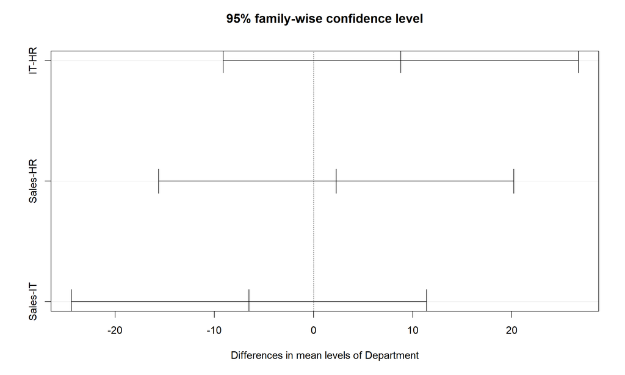

```r
plot(tukey_result)
```

# Question 5: Kruskal-Wallis H Test (Non-Parametric)

## 5.1 Kruskal-Wallis Test

```r
kruskal_result <- kruskal.test(Productivity_Score ~ Department, data = clean_data)
cat("Kruskal-Wallis Rank Sum Test:\n")
```

```
Kruskal-Wallis Rank Sum Test:
```

```r
cat("Chi-squared =", round(kruskal_result$statistic, 4), "\n")
```

```
Chi-squared = 1.4013
```

```r
cat("df =", kruskal_result$parameter, "\n")
```

```
df = 2
```

```r
cat("p-value =", round(kruskal_result$p.value, 4), "\n")
```

```
p-value = 0.4963
```

```r
if (kruskal_result$p.value < 0.05) {
    cat("\nConclusion: There is a significant difference in productivity across departments.\n")
} else {
    cat("\nConclusion: No significant difference in productivity across departments.\n")
}
```

```
Conclusion: No significant difference in productivity across departments.
```

## 5.2 Comparison with ANOVA

```r
comparison_table <- data.frame(Test = c("One-Way ANOVA", "Kruskal-Wallis H"), p_value = c(round(anova_p,
    4), round(kruskal_result$p.value, 4)), Conclusion = c(ifelse(anova_p < 0.05,
    "Significant difference", "No significant difference"), ifelse(kruskal_result$p.value <
    0.05, "Significant difference", "No significant difference")))
kable(comparison_table, caption = "Comparison of Parametric and Non-Parametric Tests",
    row.names = FALSE)
```

Comparison of Parametric and Non-Parametric Tests

| Test | p_value | Conclusion |
| --- | --- | --- |
| One-Way ANOVA | 0.4603 | No significant difference |
| Kruskal-Wallis H | 0.4963 | No significant difference |

**Interpretation:**

- **One-Way ANOVA p-value:** 0.4603
- **Kruskal-Wallis p-value:** 0.4963

# Question 6: Two-Way ANOVA

**Scenario:** Executive leadership wants to understand if productivity is influenced by Department, Work_Mode, and their interaction.

## 6.1 Two-Way ANOVA

```r
twoway_model <- aov(Productivity_Score ~ Department * Work_Mode, data = clean_data)
twoway_summary <- summary(twoway_model)
kable(twoway_summary[[1]], caption = "Two-Way ANOVA: Productivity ~ Department * Work_Mode",
    digits = 4)
```

Two-Way ANOVA: Productivity ~ Department * Work_Mode

|  | Df | Sum Sq | Mean Sq | F value | Pr(>F) |
| --- | --- | --- | --- | --- | --- |
| Department | 2 | 416.6 | 208.3000 | 0.8465 | 0.4413 |
| Work_Mode | 1 | 907.5 | 907.5000 | 3.6880 | 0.0668 |
| Department:Work_Mode | 2 | 228.6 | 114.3000 | 0.4645 | 0.6340 |
| Residuals | 24 | 5905.6 | 246.0667 | NA | NA |

## 6.2 Interaction Plot

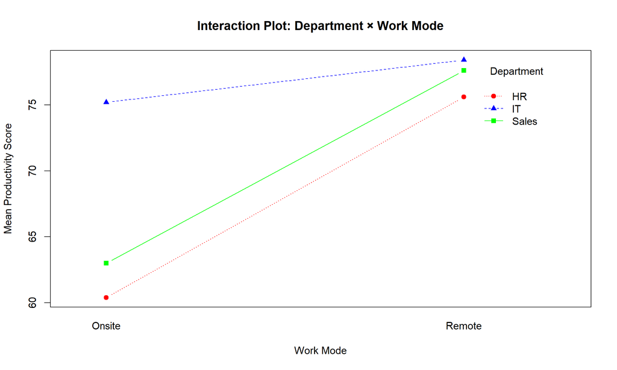

```r
interaction.plot(x.factor = clean_data$Work_Mode, trace.factor = clean_data$Department,
    response = clean_data$Productivity_Score, fun = mean, type = "b", col = c("red",
        "blue", "green"), pch = c(19, 17, 15), fixed = TRUE, legend = TRUE, xlab = "Work Mode",
    ylab = "Mean Productivity Score", trace.label = "Department", main = "Interaction Plot: Department × Work Mode")
```

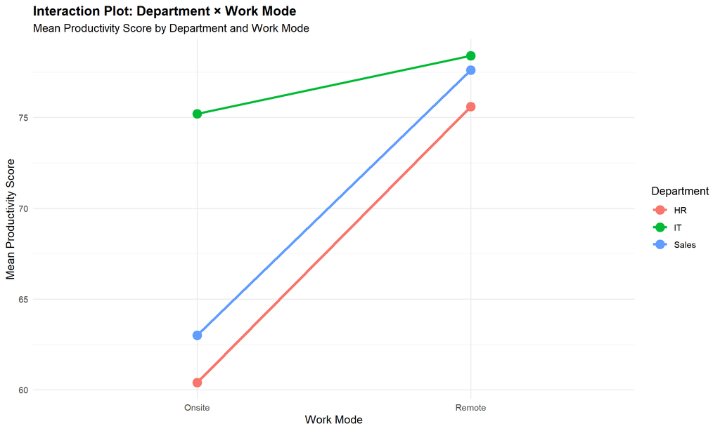

```r
clean_data %>%
    group_by(Department, Work_Mode) %>%
    summarise(Mean_Productivity = mean(Productivity_Score), .groups = "drop") %>%
    ggplot(aes(x = Work_Mode, y = Mean_Productivity, color = Department, group = Department)) +
    geom_line(size = 1.2) + geom_point(size = 4) + labs(title = "Interaction Plot: Department × Work Mode",
    subtitle = "Mean Productivity Score by Department and Work Mode", x = "Work Mode",
    y = "Mean Productivity Score", color = "Department") + theme_minimal() + theme(plot.title = element_text(face = "bold"))
```

## 6.3 Post-Hoc Tests (if interaction is significant)

```r
interaction_p <- twoway_summary[[1]]$`Pr(>F)`[3]
if (!is.na(interaction_p) && interaction_p < 0.05) {
    cat("Interaction effect is significant (p =", round(interaction_p, 4), ").\n")
    cat("Performing post-hoc analysis...\n\n")
    tukey_twoway <- TukeyHSD(twoway_model)
    kable(as.data.frame(tukey_twoway$`Department:Work_Mode`), caption = "Tukey's HSD for Department:Work_Mode Interaction",
        digits = 4)
} else {
    cat("Interaction effect is not significant (p =", round(interaction_p, 4), ").\n")
    cat("Interpreting main effects only.\n\n")
    tukey_dept <- TukeyHSD(aov(Productivity_Score ~ Department, data = clean_data))
    kable(as.data.frame(tukey_dept$Department), caption = "Tukey's HSD for Department Main Effect",
        digits = 4)
}
```

```
Interaction effect is not significant (p = 0.634 ).
Interpreting main effects only.
```

Tukey’s HSD for Department Main Effect

|  | diff | lwr | upr | p adj |
| --- | --- | --- | --- | --- |
| IT-HR | 8.8 | -9.1069 | 26.7069 | 0.4528 |
| Sales-HR | 2.3 | -15.6069 | 20.2069 | 0.9457 |
| Sales-IT | -6.5 | -24.4069 | 11.4069 | 0.6449 |

## 6.4 Interpretation

```r
dept_p <- twoway_summary[[1]]$`Pr(>F)`[1]
workmode_p <- twoway_summary[[1]]$`Pr(>F)`[2]
interaction_p <- twoway_summary[[1]]$`Pr(>F)`[3]
cat("=== Two-Way ANOVA Results ===\n\n")
```

```
=== Two-Way ANOVA Results ===
```

```r
cat("Main Effect of Department:\n")
```

```
Main Effect of Department:
```

```r
cat("  F =", round(twoway_summary[[1]]$`F value`[1], 4), ", p =", round(dept_p, 4),
    "\n")
```

```
  F = 0.8465 , p = 0.4413
```

```r
cat("  Interpretation:", ifelse(dept_p < 0.05, "Significant main effect of Department",
    "No significant main effect of Department"), "\n\n")
```

```
  Interpretation: No significant main effect of Department
```

```r
cat("Main Effect of Work_Mode:\n")
```

```
Main Effect of Work_Mode:
```

```r
cat("  F =", round(twoway_summary[[1]]$`F value`[2], 4), ", p =", round(workmode_p,
    4), "\n")
```

```
  F = 3.688 , p = 0.0668
```

```r
cat("  Interpretation:", ifelse(workmode_p < 0.05, "Significant main effect of Work_Mode",
    "No significant main effect of Work_Mode"), "\n\n")
```

```
  Interpretation: No significant main effect of Work_Mode
```

```r
cat("Interaction Effect (Department × Work_Mode):\n")
```

```
Interaction Effect (Department × Work_Mode):
```

```r
cat("  F =", round(twoway_summary[[1]]$`F value`[3], 4), ", p =", round(interaction_p,
    4), "\n")
```

```
  F = 0.4645 , p = 0.634
```

```r
cat("  Interpretation:", ifelse(interaction_p < 0.05, "Significant interaction effect - the effect of Work Mode depends on Department",
    "No significant interaction effect - the effect of Work Mode is consistent across Departments"),
    "\n")
```

```
  Interpretation: No significant interaction effect - the effect of Work Mode is consistent across Departments
```

# Summary of Findings

## Automated Summary Table

Auto-populated summary of all hypothesis tests (significance codes: *** p<0.001, ** p<0.01, * p<0.05, ns = not significant)

| Q | Analysis | Statistic | p-value | Sig. |
| --- | --- | --- | --- | --- |
| Q1 | Pearson correlation (Experience vs Stress) | r = -0.966 | < 0.001 | *** |
| Q1 | Spearman correlation (Experience vs Stress) | rho = -0.974 | < 0.001 | *** |
| Q2 | Simple linear regression (Training -> Productivity) | R2 = 0.8422 | < 0.001 | *** |
| Q3 | Multiple linear regression (Experience + Training + Stress -> Productivity) | R2 = 0.9666, adj R2 = 0.9628 | < 0.001 | *** |
| Q4 | One-Way ANOVA (Productivity ~ Department) | F = 0.799 | 0.4603 | ns |
| Q5 | Kruskal-Wallis H (Productivity ~ Department) | chi2 = 1.401, df = 2 | 0.4963 | ns |
| Q6 | Two-Way ANOVA: Department main effect | F = 0.847 | 0.4413 | ns |
| Q6 | Two-Way ANOVA: Work_Mode main effect | F = 3.688 | 0.0668 | ns |
| Q6 | Two-Way ANOVA: Department x Work_Mode interaction | F = 0.465 | 0.6340 | ns |

## Automated Interpretation

**Q1 — Correlation (Experience vs Stress).** Pearson r = -0.966 (p = < 0.001); Spearman rho = -0.974 (p = < 0.001). There is a statistically significant relationship.

**Q2 — Simple Regression (Training -> Productivity).** The model explains 84.22% of the variance in Productivity (R2 = 0.8422, p = < 0.001).

**Q3 — Multiple Regression (Experience + Training + Stress -> Productivity).** Model R2 = 0.9666 (adj R2 = 0.9628, p = < 0.001). Statistically significant predictor(s) at alpha = 0.05: Training_Hours, Stress_Index.

**Q4 — One-Way ANOVA (Productivity ~ Department).** No significant difference in mean Productivity across departments. (p = 0.4603)

**Q5 — Kruskal-Wallis H (Productivity ~ Department).** The non-parametric test finds no significant difference between departments. (p = 0.4963) The conclusion is unchanged compared with the parametric ANOVA.

**Q6 — Two-Way ANOVA (Productivity ~ Department * Work_Mode).**

- Department main effect: p = 0.4413 -> not significant.
- Work_Mode main effect: p = 0.0668 -> not significant.
- Department x Work_Mode interaction: p = 0.6340 -> no significant interaction; Work Mode effects are consistent across Departments.